# Load DVEX using DistMap

Attila Gabor

30 August 2018

## Setup the environment

```r
setwd("~/Documents/SaezGrp/LocalGitRepo/dvex")
```

Installing DistMap from GitHub using devtools package (if needed) details: https://github.com/rajewsky-lab/distmap

```r
if(!require(DistMap)){
    if(!require(devtools)) {
        install.packages("devtools")
    }
    install_github("rajewsky-lab/DistMap")
}
library(DistMap)
```

## Download the required data

```r
if(!all(file.exists(c("dge_raw.txt.gz","dge_normalized.txt.gz","binarized_bdtnp.csv.gz","bdtnp.txt.gz","geometry.txt.gz")))){
    download.file("http://bimsbstatic.mdc-berlin.de/rajewsky/DVEX/dge_raw.txt.gz",destfile = "dge_raw.txt.gz")
    download.file("http://bimsbstatic.mdc-berlin.de/rajewsky/DVEX/dge_normalized.txt.gz",destfile = "dge_normalized.txt.gz")
    download.file("http://bimsbstatic.mdc-berlin.de/rajewsky/DVEX/binarized_bdtnp.csv.gz",destfile = "binarized_bdtnp.csv.gz")
    download.file("http://bimsbstatic.mdc-berlin.de/rajewsky/DVEX/bdtnp.txt.gz",destfile = "bdtnp.txt.gz")
    download.file("http://bimsbstatic.mdc-berlin.de/rajewsky/DVEX/geometry.txt.gz",destfile = "geometry.txt.gz")
}
```

### Import raw and normalised data

decompress the downloaded dataset and import to data.frame.  
**Important**: quote is set to empty string, this way we can prevent the mis-interpretation of a gene name, that contains an apostrophe

We convert the data.frame to matrix: each column represents a cell and each row corresponds to a gene.

```r
raw.data = read.table(gzfile("dge_raw.txt.gz",'rt'),
                      sep = "\t",
                      row.names = NULL,
                      stringsAsFactors = F,
                      quote = "")
raw.data.genes = raw.data$V1
raw.data$V1 = NULL
```

Let’s fix the gene names that contains apostrophe – this would generate issues

```r
# gene names with apostrophes
print(grep("'",raw.data.genes,value = T,fixed = T))
```

```
## [1] "beta'COP" "PP2A-B'"
```

```r
raw.data.genes = gsub("'","",raw.data.genes,fixed = T)

raw.data = as.matrix(raw.data)
rownames(raw.data) = raw.data.genes
```

Repeat for the normalised data

```r
normalized.data = read.table(gzfile("dge_normalized.txt.gz",'rt'),
                             sep = "\t",
                             row.names = NULL,
                             stringsAsFactors = F,
                             quote = "")
normalized.data.genes = normalized.data$row.names
normalized.data$row.names = NULL
```

```r
# gene names with apostrophes
print(grep("'",normalized.data.genes,value = T,fixed = T))
```

```
## [1] "beta'COP" "PP2A-B'"
```

```r
normalized.data.genes = gsub("'","",normalized.data.genes,fixed = T)

normalized.data = as.matrix(normalized.data)
rownames(normalized.data) = normalized.data.genes
```

Check that the gene names are identical in the raw and normalised dataset

```r
stopifnot(all(normalized.data.genes == raw.data.genes))
```

### Import in situ datasets

```r
insitu.matrix = read.table(gzfile("binarized_bdtnp.csv.gz",'rt'), sep = ",",header = T)
insitu.genes_orig <- colnames(insitu.matrix)
```

### Match the gene names across datasets

The following few lines of code checks if there is any mismatch between the gene names.

We will find that 2 gene names were changed during the import of the dataset and the - (dash) character was changed to .(dot).

```r
# 2 gene names are not matched:
missingGenes = insitu.genes_orig[which(!insitu.genes_orig %in% normalized.data.genes)]
print(missingGenes)
```

```
## [1] "Blimp.1"      "E.spl.m5.HLH"
```

```r
# this was reported by Nikos
# lets fix this by changing the . characters in the gene names to -
insitu.genes = gsub(".","-",insitu.genes_orig,fixed = T)
# also replace .spl. --> (spl)
insitu.genes = gsub("-spl-","(spl)",insitu.genes,fixed = T)

# assert that all institu genes appear in the gene names
stopifnot(all(insitu.genes %in% raw.data.genes))
```

Now we can rename the genes in the institu.matrix with the correct names:

```r
insitu.matrix = as.matrix(insitu.matrix)
colnames(insitu.matrix) = insitu.genes
```

### Read geometry data

The column naming of the geometry is not consistent with distMap expectation, xcoord, ycoord and zcoord must be renamed to x, y, z

```r
geometry = read.csv(gzfile("geometry.txt.gz",'rt'),sep = " ")
colnames(geometry) = c("x","y","z")
```

## Run DistMap

here we just following the pipeline from https://github.com/rajewsky-lab/distmap/readme.md

```r
dm = new("DistMap",
         raw.data=raw.data,
         data=normalized.data,
         insitu.matrix=insitu.matrix,
         geometry=as.matrix(geometry))
```

```r
dm <- binarizeSingleCellData(dm, seq(0.15, 0.5, 0.01))
```

```r
# export binarised data to csv file
write.table(dm@binarized.data,file = "binarizedData_distMap.csv",sep = ",",row.names = T,col.names = T)

dm <- mapCells(dm)

pha = computeVISH(dm, 'sna', threshold=0.75)
```

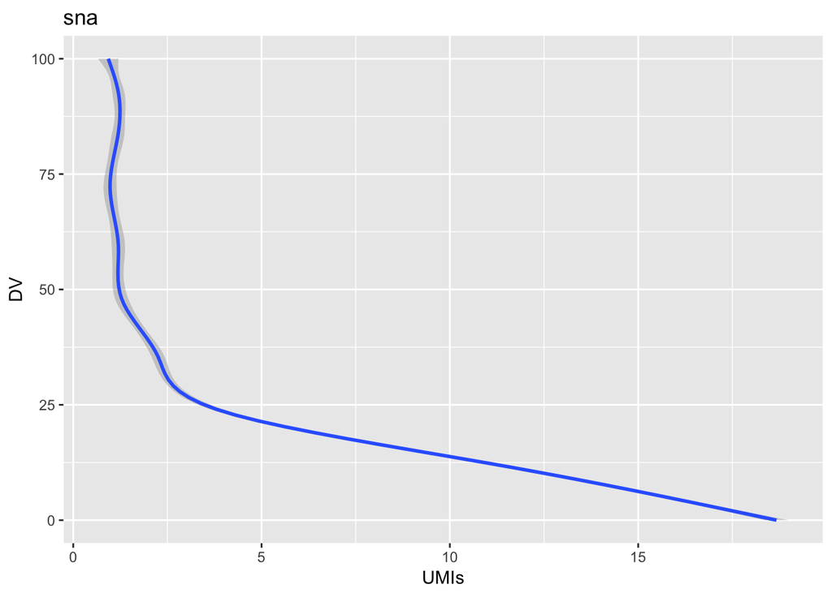

```r
computeGeneGradient(dm, 'sna')
```